# Twitter Analysis

David Rodriguez

February 24, 2016

## Introduction

Twitter is a powerful two-edged tool that enables users to communicate with others and also empowers data scientists with large quantities of data they can use.

## Experiment Setup

Load up required packages:

```r
library(twitteR)
library(tm)
library(rjson)
library(wordcloud)
library(dplyr)
library(caret)
library(knitr)
library(RColorBrewer)
```

Read in my application credentials:

```r
secrets <- fromJSON(file='twitter_secrets.json.nogit')

setup_twitter_oauth(secrets$api_key,
                    secrets$api_secret,
                    secrets$access_token,
                    secrets$access_token_secret)
```

Perform a twitter search and extract the information we want:

```r
searchstring <- 'python'
numtweets <- 1000
st <- searchTwitter(searchstring, n=numtweets, resultType = 'recent', lang = 'en')

st_text <- sapply(st, function(x) x$getText())
st_user <- sapply(st, function(x) x$getScreenName())
st_rts <- sapply(st, function(x) x$isRetweet)
st_lat <- sapply(st, function(x) as.numeric(x$latitude[1]))
st_lon <- sapply(st, function(x) as.numeric(x$longitude[1]))
st_time <- sapply(st, function(x) format(x$created, format='%F %T'))

statuses <- data.frame('text'=st_text, 'user'=st_user, 'RT'=st_rts,
                       'latitude'=st_lat, 'longitude'=st_lon,
                       'time'=st_time)
```

Remove retweets for clarity:

```r
statuses <-
    statuses %>%
    filter(!RT)
```

To save time, we’ll load up saved tweets:

```r
#saveRDS(statuses, file='tweet_data.Rda')
statuses <- readRDS(file='data/tweet_data.Rda')
```

Total number of tweets to process is 4430

## Text Analysis

Gather the tweets:

```r
textdata <- Corpus(VectorSource(statuses$text))

textdata <- tm_map(textdata, removeWords, stopwords("english"), mc.cores=1)
textdata <- tm_map(textdata, removePunctuation, mc.cores=1)
textdata <- tm_map(textdata,
                   content_transformer(function(x) iconv(x, to='UTF-8-MAC', sub='byte')),
                   mc.cores=1)
textdata <- tm_map(textdata, content_transformer(tolower), mc.cores=1)
textdata <- tm_map(textdata, stripWhitespace, mc.cores=1)
```

A quick wordcloud:

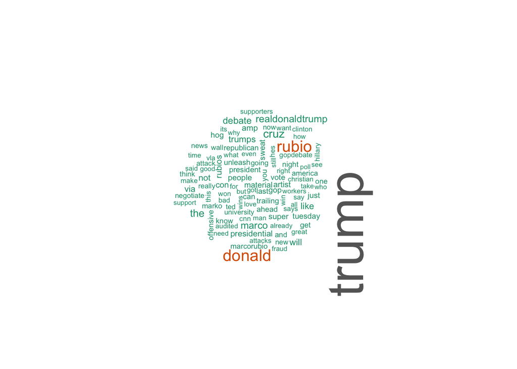

```r
pal2 <- brewer.pal(8,"Dark2")
wordcloud(textdata, max.words = 100, colors= pal2)
```

Further processing to get word counts:

```r
dtm <- DocumentTermMatrix(textdata)
dtm <- inspect(dtm)

words <- data.frame(term = colnames(dtm))
words$count <- colSums(dtm)
```

Sort in descending order:

```r
words <-
    words %>%
    arrange(desc(count))
head(words)
```

```
##              term count
## 1           trump  4207
## 2          donald   980
## 3           rubio   954
## 4            cruz   509
## 5             the   417
## 6 realdonaldtrump   370
```

Convert tweets to data frame:

```r
tweets <- as.data.frame(dtm)
ind <- data.frame('id'=seq.int(nrow(tweets)))
tweets <- cbind(ind, tweets)
rm(dtm, textdata) # clearing up memory
```

Select only the top 100 words (not the search term) to process:

```r
words_100 <- as.character(words[2:101,'term'])
```

Use only those variables to process the tweets:

```r
tweets <- tweets[,c('id',words_100)]
head(tweets[,1:10])
```

```
##   id donald rubio cruz the realdonaldtrump marco debate like will
## 1  1      0     0    0   0               0     0      0    0    0
## 2  2      1     0    0   1               0     0      0    0    0
## 3  3      0     1    1   0               0     0      0    0    0
## 4  4      0     1    0   0               0     0      0    0    0
## 5  5      0     0    0   0               0     0      0    0    1
## 6  6      0     1    0   0               0     0      0    0    0
```

## PCA

Perform a principal component analysis on the tweet data set:

```r
trans <- preProcess(tweets[,2:ncol(tweets)], method=c("pca"), thresh = 0.95)
pca <- predict(trans, tweets[,2:ncol(tweets)])
```

Examine reprojected data

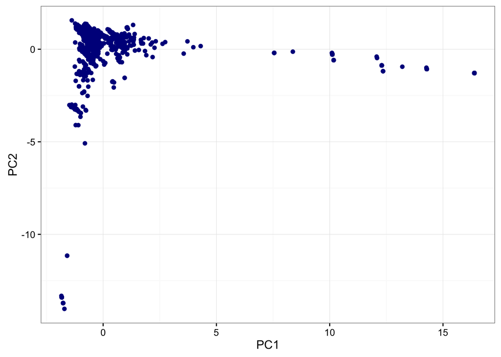

```r
ggplot(pca, aes(x=PC1, y=PC2)) +
    geom_point(color='dark blue') +
    theme_bw()
```

Look at loading factors:

```r
loadings <- trans$rotation
load_sqr <- loadings^2

load_sqr <- data.frame(load_sqr)
temp <- data.frame('term'=rownames(load_sqr))
load_sqr <- cbind(temp, load_sqr)
load_sqr %>%
    select(term, PC1) %>%
    arrange(desc(PC1)) %>%
    head(10)
```

```
##            term        PC1
## 1           hog 0.11687516
## 2         sweat 0.11687516
## 3      material 0.11476995
## 4  presidential 0.09974336
## 5         marko 0.09920559
## 6        rubios 0.08979297
## 7           not 0.08735209
## 8     negotiate 0.08643050
## 9           vla 0.07641684
## 10        marco 0.06167758
```

```r
load_sqr %>%
    select(term, PC2) %>%
    arrange(desc(PC2)) %>%
    head(10)
```

```
##         term          PC2
## 1   trailing 0.1547439207
## 2    unleash 0.1532751119
## 3  offensive 0.1523377746
## 4      ahead 0.1497500404
## 5    tuesday 0.1428838321
## 6      super 0.1374500343
## 7       cruz 0.0498305493
## 8      rubio 0.0308085237
## 9       news 0.0021403225
## 10     marko 0.0009864695
```

Join the PCA information (first five components) to the original status array:

```r
statuses <- cbind(statuses, pca[,1:5])
```

I can now examine the tweets based on where they fall in principal component space.

I’ve created a function to sample tweets across the PC spectrum.

```r
set.seed(42)
tweet_check <- function(text, pc, numbreaks=5){
    cuts <- cut(pc, numbreaks)
    temp <- data.frame(text=text, pc=pc, pc_val=cuts)
    temp <- temp %>%
        group_by(pc_val) %>%
        summarise(text=sample(text,1))
    return(temp)
}
```

Here are the results for PC1:

```r
tweet_check(statuses$text, statuses$PC1, 10) %>% kable(format='html')
```

| pc_val | text |
| --- | --- |
| (-1.86,-0.0195] | Hmm…I wonder what @ESQPolitics will have to say about this one? https://t.co/7X7Boawwr0 |
| (-0.0195,1.8] | @DT_Stephenson Trump spanked Rubio ! Rubio tried to yell at Trump with that mouse voice. Rubio is no President. |
| (1.8,3.63] | Fact checking the 10th Republican debate: Republican presidential candidates Marco Rubio (L) and Donald Trump … https://t.co/TGBBULM7jL |
| (3.63,5.45] | Leightweight spellur Donald Trump continues to address the poorly educated. Not presidential material! #mrmeltdown https://t.co/sDAmntzEfs |
| (7.27,9.09] | #DonaldTrump – #MarcoRubio’s a Sweat Hog … Not Presidential Material #MarkoRubio… https://t.co/pyE4Q2cNmE https://t.co/H4vjpxMNEy |
| (9.09,10.9] | Donald Trump – Marco Rubio’s a Sweat Hog … Not Presidential Material https://t.co/rfV8yUX5xf #TMZ #showbiz |
| (10.9,12.7] | Donald Trump – Marco Rubio’s a Sweat Hog … Not Presidential Material: Marko Rubio c… https://t.co/oNVzkqEhBC #YMDLU.com |
| (12.7,14.6] | Donald Trump – Marco Rubio’s a Sweat Hog … Not Presidential Material: Marko Rubio cannot negotiate wit… https://t.co/SOxWNnlkjO #TMZ |
| (14.6,16.4] | Donald Trump – Marco Rubio’s a Sweat Hog … Not Presidential Material: Marko Rubio cannot negotiate with Vla… https://t.co/HDx3aXm6h7 |

And here are the results for PC2:

```r
tweet_check(statuses$text, statuses$PC2, 10) %>% kable(format='html')
```

pc_val

text

(-14,-12.5]

Trailing ahead of Super Tuesday, Cruz and Rubio unleash a Trump offensive: https://t.co/4SXYiYoylq

(-12.5,-10.9]

♥ #LaMente_Macabra ♥ Trailing ahead of Super Tuesday, Cruz and Rubio unleash a Trump … https://t.co/jgxgTutuXO ♥ #LaMente_Macabra ♥

(-6.23,-4.67]

BBC News US Republican contest: Five ways Cruz and Rubio double-teamed Trump BBC News With the Super Tuesday… https://t.co/Qsl7YfcJso

(-4.67,-3.12]

@marcorubio I may not be a Republican but you are the best person to take out Trump before Super Tuesday. Don’t let him win! #GOPDebate

(-3.12,-1.56]

1. Trump stood tall controled debait. Allso looked like the president. Super Tuesday will show he’s the man! Vote Trump

(-1.56,0.000902]

@SouvenirCity Agreed. Kasich and Cruz voters likely to Rubio. Carson voters likely to Trump. Should get interesting.

(0.000902,1.58]

Rubio: My disastrous failure to stop Trump is the media’s fault https://t.co/zh5Dkh8u7Q via @ThePlumLineGS

Saving the processed tweets to continue work elsewhere:

```r
saveRDS(statuses, file='data/proc_tweets.Rda')
```